# 1 - Data visualization

## 1.1 Introduccion

Vamos usar para graficar todo **ggplot2**, el cual es el estandar para graficar. En ste capitulo vamosa ver como visualizar data usando **ggplot2*

### 1.1.1 - Pre requisitos

Tenemos que instalar primero tidiverse, para eso usamos la sintaxis clasica de R para importar librerias

```
install.packages("tidyverse")
```

[output not shown]

```
library(tidyverse)
```

Algo importante es que, al igual que en python, las librerias deben cargarse cada vez que se vayan a utilizar.

Ademas de tidiverse, vamos a usar el paquete **palmerpenguins**. Que incluye un datasetu de pinguinos y el paquete **ggthemes** que tiene color amigables para los daltonicos.

```
install.packages("palmerpenguins")
install.packages("ggthemes")

library(palmerpenguins)
library(ggthemes)
```

## 1.2 - Primeros pasos

Vamos a crear visualizaciones para poder visualizar diferentes relaciones entre los atributos del dataset

### 1.2.1 - El dataset de pinguinos

Algunas definciones: - Una **variable** es una cantidad, cualidad o propiedad que se puede medir. - Un **valor** es el estado de una variable cuando se la mide. - Una **observacion** es un set de mediciones hechas sobre condiciones similares.

Vamos a ver un primer vistaso el dataset de pinguinos. En tidyverse usamos un tipo especial de dataframes llamados **tibbles**

| species | island | bill_length_mm | bill_depth_mm | flipper_length_mm | body_mass_g | sex | year |
| --- | --- | --- | --- | --- | --- | --- | --- |
| Adelie | Torgersen | 39.1 | 18.7 | 181 | 3750 | male | 2007 |
| Adelie | Torgersen | 39.5 | 17.4 | 186 | 3800 | female | 2007 |
| Adelie | Torgersen | 40.3 | 18.0 | 195 | 3250 | female | 2007 |
| Adelie | Torgersen | NA | NA | NA | NA | NA | 2007 |
| Adelie | Torgersen | 36.7 | 19.3 | 193 | 3450 | female | 2007 |
| Adelie | Torgersen | 39.3 | 20.6 | 190 | 3650 | male | 2007 |
| Adelie | Torgersen | 38.9 | 17.8 | 181 | 3625 | female | 2007 |
| Adelie | Torgersen | 39.2 | 19.6 | 195 | 4675 | male | 2007 |
| Adelie | Torgersen | 34.1 | 18.1 | 193 | 3475 | NA | 2007 |
| Adelie | Torgersen | 42.0 | 20.2 | 190 | 4250 | NA | 2007 |

[output cut: 334 more lines]

Vemos que el dataframe tiene 8 columns. Para una vista alternativa, donde podamos ver todas las viarables podemos tener una ver las primeras observaciones de todas las variables usando glimpse() o view(datset)

```
glimpse(penguins)
```

```
Rows: 344
Columns: 8
$ species           <fct> Adelie, Adelie, Adelie, Adelie, Adelie, Adelie, Adelie, Adelie, Adelie, Adelie, Adeli…
$ island            <fct> Torgersen, Torgersen, Torgersen, Torgersen, Torgersen, Torgersen, Torgersen, Torgerse…
$ bill_length_mm    <dbl> 39.1, 39.5, 40.3, NA, 36.7, 39.3, 38.9, 39.2, 34.1, 42.0, 37.8, 37.8, 41.1, 38.6, 34.…
$ bill_depth_mm     <dbl> 18.7, 17.4, 18.0, NA, 19.3, 20.6, 17.8, 19.6, 18.1, 20.2, 17.1, 17.3, 17.6, 21.2, 21.…
$ flipper_length_mm <int> 181, 186, 195, NA, 193, 190, 181, 195, 193, 190, 186, 180, 182, 191, 198, 185, 195, 1…
$ body_mass_g       <int> 3750, 3800, 3250, NA, 3450, 3650, 3625, 4675, 3475, 4250, 3300, 3700, 3200, 3800, 440…
$ sex               <fct> male, female, female, NA, female, male, female, male, NA, NA, NA, NA, female, male, m…
$ year              <int> 2007, 2007, 2007, 2007, 2007, 2007, 2007, 2007, 2007, 2007, 2007, 2007, 2007, 2007, 2…
```

### 1.2.2 - Nuestro objetivo

Vamos a querer reproducir este grafico

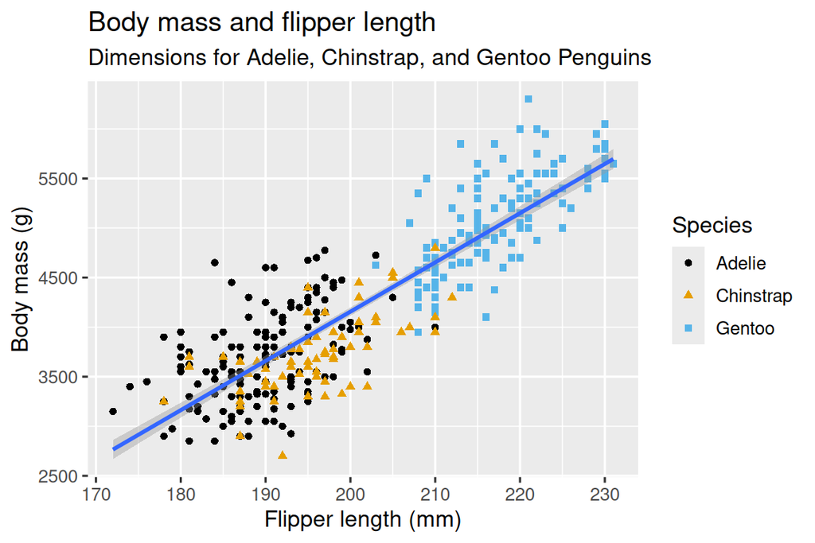

### 1.2.3 - Creando un ggplot

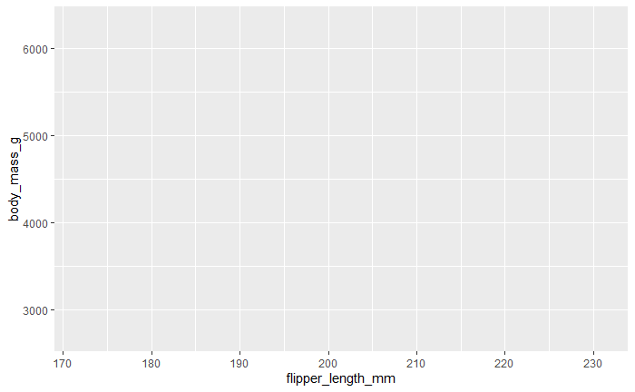

Vamos a agregarle la data ahora

```
ggplot(
  data = penguins,
  mapping = aes(x = flipper_length_mm, y = body_mass_g)
) +
  geom_point()
```

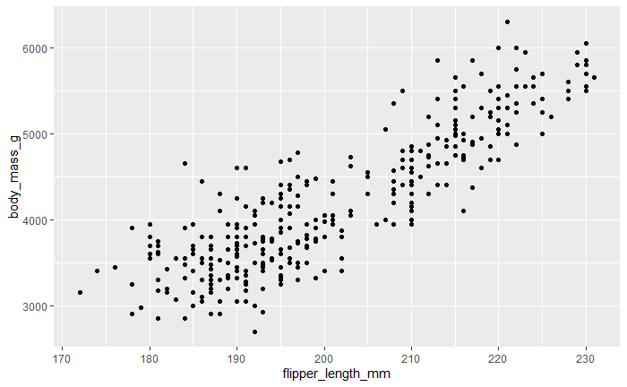

### 1.2.4

Vamos a incorporar ahora un poco mas decolor a nuestro grafico para poder entendermejor las relaciones. Para esto vamos a empezar a modificar nuestro codigo en la parte de aes(), ya que este es el mapeo estetico del plot.

```
ggplot(
  data = penguins,
  mapping = aes(x = flipper_length_mm, y = body_mass_g, color = species)
) +
  geom_point()
```

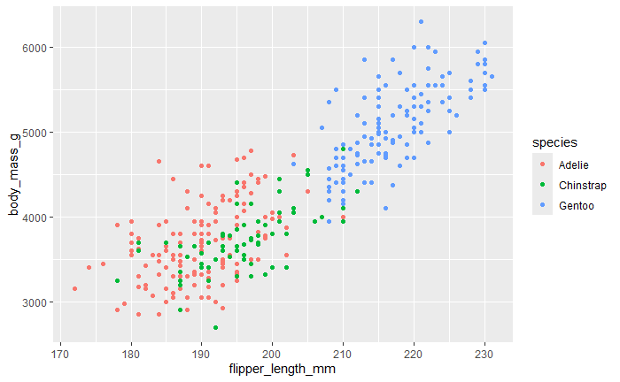

Ahora vamos a agregar algo mas, vamos a agregar una linea que nos marque la tendencia para cada clase.

```
ggplot(
  data = penguins,
  mapping = aes(x = flipper_length_mm, y = body_mass_g, color = species)
) +
  geom_point() +
  geom_smooth(method = "lm")
```

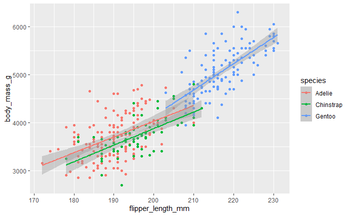

Ahora bien, el grafico que queremos replicar tiene una linea global, no una por clase. Esto pasa porque cuando le pasamos argumentos a la capa de mapeo estetico, esto despues se pasa de manera implicita para cada subcapa. Lo que hay que hacer es poner el argumeneto solo donde querramos modificar

```
ggplot(
  data = penguins,
  mapping = aes(x = flipper_length_mm, y = body_mass_g)
) +
  geom_point(mapping = aes(color = species)) +
  geom_smooth(method = "lm")
```

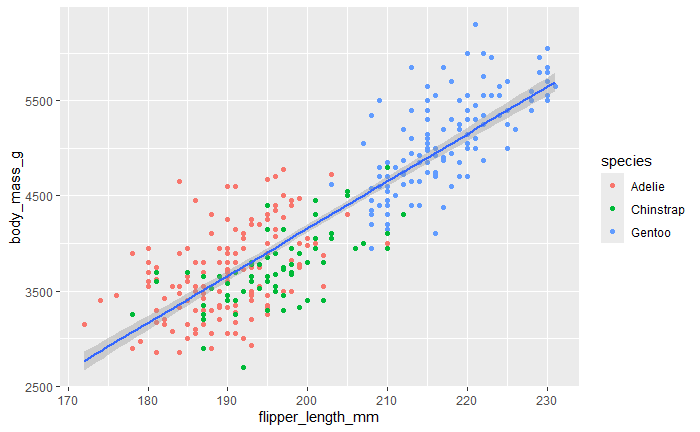

Vemos que ahora el color esta solo en la subcapa de **geom_point**. Para terminar podemos agregarle ademas que cada clase tenga una figura diferente

```
ggplot(
  data = penguins,
  mapping = aes(x = flipper_length_mm, y = body_mass_g)
) +
  geom_point(mapping = aes(color = species, shape = species)) +
  geom_smooth(method = "lm")
```

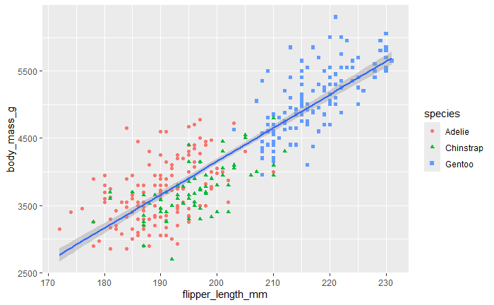

```
ggplot(
  data = penguins,
  mapping = aes(x = flipper_length_mm, y = body_mass_g)
) +
  geom_point(aes(color = species, shape = species)) +
  geom_smooth(method = "lm") +
  labs(
    title = "Body mass and flipper length",
    subtitle = "Dimensions for Adelie, Chinstrap, and Gentoo Penguins",
    x = "Flipper length (mm)", y = "Body mass (g)",
    color = "Species", shape = "Species"
  ) +
  scale_color_colorblind()
```

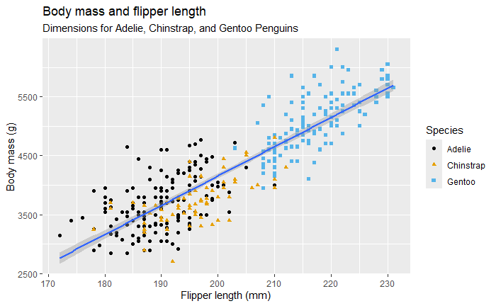

## 1.5 Ejercicios

### 1.

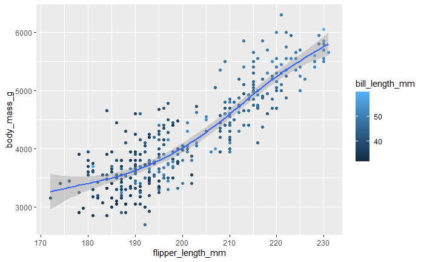

## 1.3 - ggplot2 calss

Vamos a ver expresiones mas concisas de codigo de ggplot2. Hasta ahora fuimos muy explicitos

```
ggplot(
  data = penguins,
  mapping = aes(x = flipper_length_mm, y = body_mass_g)
) +
  geom_point()
```

Los primeros dos argumentos de ggplot son tan imporatntes que ya deberias saberlos de memoria, por lo que no vamos a escribirlos mas. Estaran puestos de manera implicita

```
ggplot(penguins, aes(x = flipper_length_mm, y = body_mass_g)) +
  geom_point()
```

Dentro de poco, tambien aprenderemos a usar el pipe operator, |>, que nos deja crear plots como

```
penguins |>
  ggplot(aes(x = flipper_length_mm, y = body_mass_g)) +
  geom_point()
```

## 1.4 - Visualizando distribuciones

Vamosa ver como visualizar distribuciones de variables numericas y categoricas. ### 1.4.1 Categoricas La manera mas sencillas de graficar este tipo de distribucioens es usansdo un grafico de barras En ggplot existe el geom de barra

```
ggplot(penguins, aes(x = species)) +
  geom_bar()
```

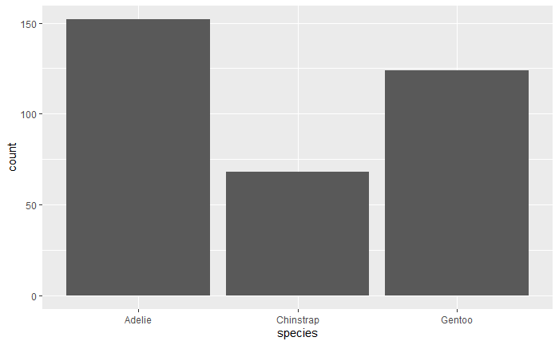

En estos casos como no tenemos clases que tienen una jerarquia natural, es comun querer ordenar por frecuencia

```
ggplot(penguins, aes(x = fct_infreq(species))) +
  geom_bar()
```

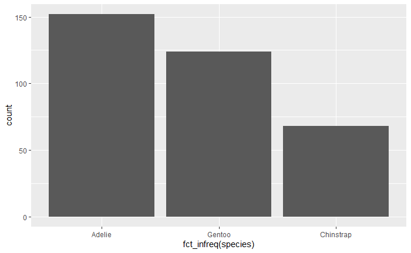

## 1.4.2 Numericas

Las variables numericas en general se muestran usando histogramas

```
ggplot(penguins, aes(x = body_mass_g)) +
  geom_histogram(binwidth = 200)
```

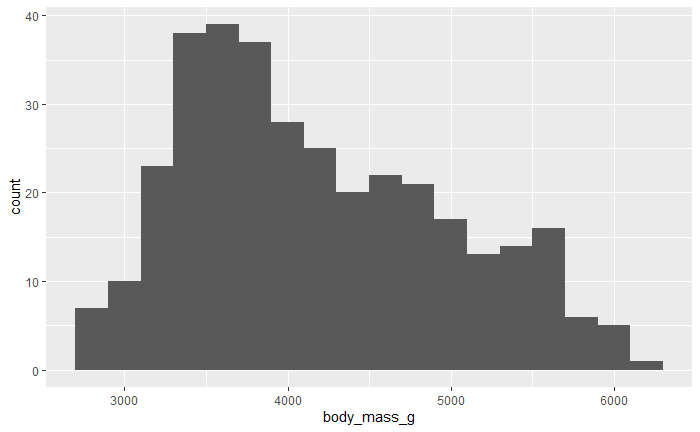

Como ya sabemos, uno de los aspectos criticos de un histograma es el tamaño del bin, ya que nos habla de la resolucion en la contabiulizacion. A continuacion se muestran dos casos extremos de bins

```
ggplot(penguins, aes(x = body_mass_g)) +
  geom_histogram(binwidth = 20)
```

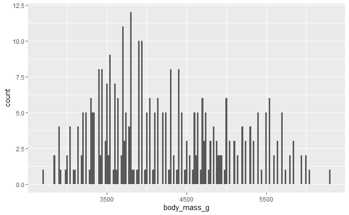

```
ggplot(penguins, aes(x = body_mass_g)) +
  geom_histogram(binwidth = 2000)
```

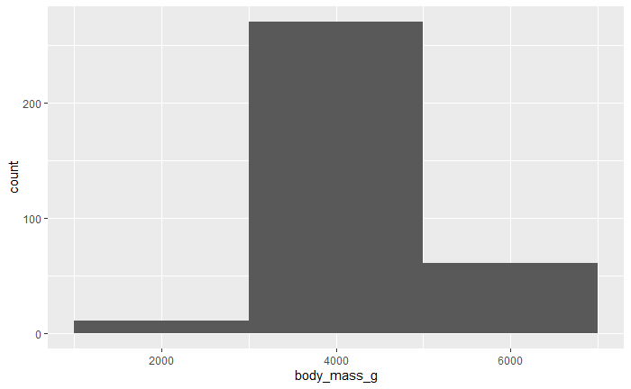

Tambien otra opcion que existe es el de un diagrma de densidad

```
ggplot(penguins, aes(x = body_mass_g)) +
  geom_density()
```

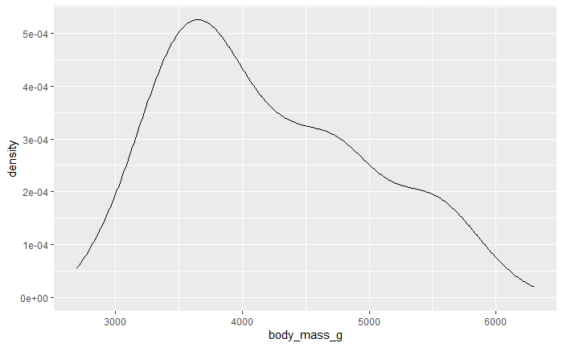

## Visualizando relaciones

Para visualizar relaciones necesitamos tener al menso dos variables mappeadas a la aestetics de un plot.

### 1.5.1 Una numerica y una categorica